# Step 2:

Select a 3-year time period and use daily data.

**a. Import, structure, and graph the daily factor returns.**

```python
from google.colab import drive
from google.colab import files

# Mount Google Drive
drive.mount('/content/drive')

# Use the file picker to upload a file
uploaded = files.upload()

# Print the uploaded file(s)
for filename in uploaded.keys():
    print(f'Uploaded file: "{filename}"')
```

Upload widget is only available when the cell has been executed in the current browser session. Please rerun this cell to enable.

```
Saving F-F_Research_Data_5_Factors_2x3_daily.xlsx to F-F_Research_Data_5_Factors_2x3_daily.xlsx
Uploaded file: "F-F_Research_Data_5_Factors_2x3_daily.xlsx"
```

```python
import pandas as pd

file_name = 'F-F_Research_Data_5_Factors_2x3_daily.xlsx'

# Create DataFrame
data = pd.read_excel(file_name)

print(data.head())
```

```
       Date  Mkt-RF   SMB   HML   RMW   CMA     RF
0  19630701   -0.67  0.02 -0.35  0.03  0.13  0.012
1  19630702    0.79 -0.28  0.28 -0.08 -0.21  0.012
2  19630703    0.63 -0.18 -0.10  0.13 -0.25  0.012
3  19630705    0.40  0.09 -0.28  0.07 -0.30  0.012
4  19630708   -0.63  0.07 -0.20 -0.27  0.06  0.012
```

```python
#Choosing 3 years worth of data

import pandas as pd

data['Date'] = pd.to_datetime(data['Date'], format='%Y%m%d')

# Dates
start_date = '2021-01-01'
end_date = '2023-12-31'

filtered_data = data[(data['Date'] >= start_date) & (data['Date'] <= end_date)]

print(filtered_data)
```

```
            Date  Mkt-RF   SMB   HML   RMW   CMA     RF
14476 2021-01-04   -1.41  0.16  0.58 -0.64  0.10  0.000
14477 2021-01-05    0.86  1.32  0.49  0.36  0.55  0.000
14478 2021-01-06    0.79  3.15  3.94  0.06  0.53  0.000
14479 2021-01-07    1.76  0.02 -0.83 -1.50 -0.20  0.000
14480 2021-01-08    0.51 -1.01 -1.37 -0.43 -0.37  0.000
...          ...     ...   ...   ...   ...   ...    ...
15224 2023-12-22    0.21  0.61  0.09 -0.64  0.19  0.021
15225 2023-12-26    0.48  0.81  0.46 -0.34 -0.15  0.021
15226 2023-12-27    0.16  0.16  0.12 -0.31 -0.14  0.021
15227 2023-12-28   -0.01 -0.38  0.03 -0.32  0.15  0.021
15228 2023-12-29   -0.43 -1.13 -0.37  0.67 -0.07  0.021

[753 rows x 7 columns]
```

```python
# daily factor returns
filtered_data['Mkt-RF_returns'] = filtered_data['Mkt-RF'].diff()
filtered_data['SMB_returns'] = filtered_data['SMB'].diff()
filtered_data['HML_returns'] = filtered_data['HML'].diff()
filtered_data['RMW_returns'] = filtered_data['RMW'].diff()
filtered_data['CMA_returns'] = filtered_data['CMA'].diff()

# Create a new DataFrame with only daily returns columns
daily_returns = filtered_data[['Mkt-RF_returns', 'SMB_returns', 'HML_returns', 'RMW_returns', 'CMA_returns']]

# Display the DataFrame with daily returns
print(daily_returns)
```

```
       Mkt-RF_returns  SMB_returns  HML_returns  RMW_returns  CMA_returns
14476             NaN          NaN          NaN          NaN          NaN
14477            2.27         1.16        -0.09         1.00         0.45
14478           -0.07         1.83         3.45        -0.30        -0.02
14479            0.97        -3.13        -4.77        -1.56        -0.73
14480           -1.25        -1.03        -0.54         1.07        -0.17
...               ...          ...          ...          ...          ...
15224           -0.88        -0.14         0.12        -0.07         0.36
15225            0.27         0.20         0.37         0.30        -0.34
15226           -0.32        -0.65        -0.34         0.03         0.01
15227           -0.17        -0.54        -0.09        -0.01         0.29
15228           -0.42        -0.75        -0.40         0.99        -0.22

[753 rows x 5 columns]
```

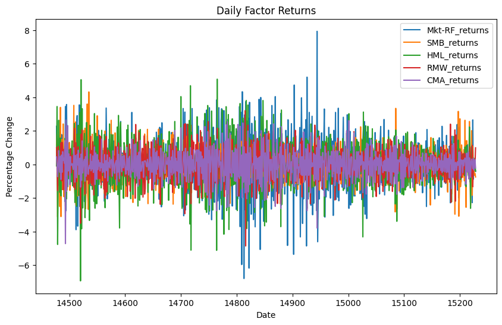

```python
# Plot the daily returns

import matplotlib.pyplot as plt

daily_returns.plot(figsize=(10, 6), title='Daily Factor Returns')
plt.xlabel('Date')
plt.ylabel('Percentage Change')
plt.legend(loc='upper right')
plt.show()
```

**b. Collect and compute correlations of the changes in the factor returns.**

```python
# Compute the correlation matrix
correlation_matrix = daily_returns.corr()

# Display the correlation matrix
print(correlation_matrix)
```

```
                Mkt-RF_returns  SMB_returns  HML_returns  RMW_returns  \
Mkt-RF_returns        1.000000     0.229101    -0.370791    -0.330853
SMB_returns           0.229101     1.000000     0.147876    -0.397704
HML_returns          -0.370791     0.147876     1.000000     0.422371
RMW_returns          -0.330853    -0.397704     0.422371     1.000000
CMA_returns          -0.478364     0.008838     0.733446     0.360897

                CMA_returns
Mkt-RF_returns    -0.478364
SMB_returns        0.008838
HML_returns        0.733446
RMW_returns        0.360897
CMA_returns        1.000000
```

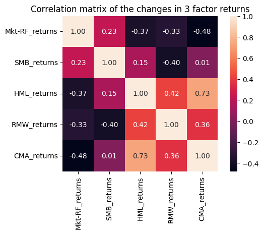

```python
import seaborn as sns
import matplotlib.pyplot as plt
fig, ax = plt.subplots(figsize=(6,4))
sns.heatmap(correlation_matrix, annot=True, fmt='.2f', ax=ax, square=True)
ax.set_title('Correlation matrix of the changes in 3 factor returns')
plt.show()
```

**c. Collect economic data of your choice during that 2-year period (for example, inflation rates, 10-year Treasury rates, etc.)**

```python
import yfinance as yf

# Dates
start_date = '2022-01-01'
end_date = '2024-01-01'

# Downloan 10-year Treasury rate data
treasury_data = yf.download('^TNX', start=start_date, end=end_date)

print(treasury_data.head())
```

```
             Open   High    Low  Close  Adj Close  Volume
Date
2022-01-03  1.534  1.635  1.533  1.628      1.628       0
2022-01-04  1.663  1.686  1.654  1.668      1.668       0
2022-01-05  1.660  1.710  1.647  1.705      1.705       0
2022-01-06  1.733  1.744  1.721  1.733      1.733       0
2022-01-07  1.739  1.801  1.727  1.771      1.771       0
```

# Step 3:

Using the data, find the FF3 betas.

**a. Use LS and a robust version to run the regressions. Please specify how you divided data into training and testing. There are many ways to do this, as you learned in ML.**

```python
ff5 = daily_returns
ff3 = daily_returns[['Mkt-RF_returns', 'CMA_returns', 'SMB_returns', 'HML_returns']]
ff3
```

|  | Mkt-RF_returns | CMA_returns | SMB_returns | HML_returns |
| --- | --- | --- | --- | --- |
| 14476 | NaN | NaN | NaN | NaN |
| 14477 | 2.27 | 0.45 | 1.16 | -0.09 |
| 14478 | -0.07 | -0.02 | 1.83 | 3.45 |
| 14479 | 0.97 | -0.73 | -3.13 | -4.77 |
| 14480 | -1.25 | -0.17 | -1.03 | -0.54 |
| ... | ... | ... | ... | ... |
| 15224 | -0.88 | 0.36 | -0.14 | 0.12 |
| 15225 | 0.27 | -0.34 | 0.20 | 0.37 |
| 15226 | -0.32 | 0.01 | -0.65 | -0.34 |
| 15227 | -0.17 | 0.29 | -0.54 | -0.09 |
| 15228 | -0.42 | -0.22 | -0.75 | -0.40 |

753 rows × 4 columns

```python
ff5
```

|  | Mkt-RF_returns | SMB_returns | HML_returns | RMW_returns | CMA_returns |
| --- | --- | --- | --- | --- | --- |
| 14476 | NaN | NaN | NaN | NaN | NaN |
| 14477 | 2.27 | 1.16 | -0.09 | 1.00 | 0.45 |
| 14478 | -0.07 | 1.83 | 3.45 | -0.30 | -0.02 |
| 14479 | 0.97 | -3.13 | -4.77 | -1.56 | -0.73 |
| 14480 | -1.25 | -1.03 | -0.54 | 1.07 | -0.17 |
| ... | ... | ... | ... | ... | ... |
| 15224 | -0.88 | -0.14 | 0.12 | -0.07 | 0.36 |
| 15225 | 0.27 | 0.20 | 0.37 | 0.30 | -0.34 |
| 15226 | -0.32 | -0.65 | -0.34 | 0.03 | 0.01 |
| 15227 | -0.17 | -0.54 | -0.09 | -0.01 | 0.29 |
| 15228 | -0.42 | -0.75 | -0.40 | 0.99 | -0.22 |

753 rows × 5 columns

```python
import statsmodels.api as sm
import numpy as np
from sklearn.model_selection import train_test_split

# Combine the factors into a design matrix
X = ff3[['CMA_returns', 'SMB_returns', 'HML_returns']]
y = ff3['Mkt-RF_returns']

# handle missing or infinite values
if X.isnull().values.any() or not np.isfinite(X.values).all() or y.isnull().values.any() or not np.isfinite(y.values).all():
    # Replace infinite values with NaN
    X.replace([np.inf, -np.inf], np.nan, inplace=True)
    y.replace([np.inf, -np.inf], np.nan, inplace=True)

    # Drop rows with NaN values
    combined_data = pd.concat([X, y], axis=1)
    combined_data = combined_data.dropna()

    # Separate the cleaned data
    X = combined_data[['Mkt-RF_returns', 'CMA_returns', 'SMB_returns', 'HML_returns']]
    y = combined_data['Mkt-RF_returns']

# Split the data into training and testing sets
X_train, X_test, y_train, y_test = train_test_split(X, y, test_size=0.2, random_state=42)

# Fit the Ordinary Least Squares (OLS) regression model
model_ols = sm.OLS(y_train, sm.add_constant(X_train)).fit()

# Fit the Robust regression model
model_robust = sm.RLM(y_train, sm.add_constant(X_train)).fit()

# Print the summary of the OLS regression
print("OLS Regression Summary:")
print(model_ols.summary())

# Print the summary of the Robust regression
print("\nRobust Regression Summary:")
print(model_robust.summary())
```

```
OLS Regression Summary:
                            OLS Regression Results
==============================================================================
Dep. Variable:         Mkt-RF_returns   R-squared:                       1.000
Model:                            OLS   Adj. R-squared:                  1.000
Method:                 Least Squares   F-statistic:                 1.270e+32
Date:                Thu, 08 Feb 2024   Prob (F-statistic):               0.00
Time:                        15:18:29   Log-Likelihood:                 19556.
No. Observations:                 601   AIC:                        -3.910e+04
Df Residuals:                     596   BIC:                        -3.908e+04
Df Model:                           4
Covariance Type:            nonrobust
==================================================================================
                     coef    std err          t      P>|t|      [0.025      0.975]
----------------------------------------------------------------------------------
const          -1.284e-16   7.33e-17     -1.753      0.080   -2.72e-16    1.55e-17
Mkt-RF_returns     1.0000   5.31e-17   1.88e+16      0.000       1.000       1.000
CMA_returns     6.731e-16   1.27e-16      5.283      0.000    4.23e-16    9.23e-16
SMB_returns    -2.507e-17   7.42e-17     -0.338      0.736   -1.71e-16    1.21e-16
HML_returns    -3.171e-16   7.21e-17     -4.396      0.000   -4.59e-16   -1.75e-16
==============================================================================
Omnibus:                       20.227   Durbin-Watson:                   2.013
Prob(Omnibus):                  0.000   Jarque-Bera (JB):               47.292
Skew:                          -0.037   Prob(JB):                     5.38e-11
Kurtosis:                       4.372   Cond. No.                         3.75
==============================================================================

Notes:
[1] Standard Errors assume that the covariance matrix of the errors is correctly specified.

Robust Regression Summary:
                    Robust linear Model Regression Results
==============================================================================
Dep. Variable:         Mkt-RF_returns   No. Observations:                  601
Model:                            RLM   Df Residuals:                      596
Method:                          IRLS   Df Model:                            4
Norm:                          HuberT
Scale Est.:                       mad
Cov Type:                          H1
Date:                Thu, 08 Feb 2024
Time:                        15:18:29
No. Iterations:                    50
==================================================================================
                     coef    std err          z      P>|z|      [0.025      0.975]
----------------------------------------------------------------------------------
const           3.168e-17   6.68e-17      0.475      0.635   -9.92e-17    1.63e-16
Mkt-RF_returns     1.0000   4.84e-17   2.07e+16      0.000       1.000       1.000
CMA_returns    -5.586e-16   1.16e-16     -4.813      0.000   -7.86e-16   -3.31e-16
SMB_returns    -4.716e-16   6.76e-17     -6.973      0.000   -6.04e-16   -3.39e-16
HML_returns      2.44e-16   6.57e-17      3.713      0.000    1.15e-16    3.73e-16
==================================================================================

If the model instance has been used for another fit with different fit parameters, then the fit options might not be the correct ones anymore .
```

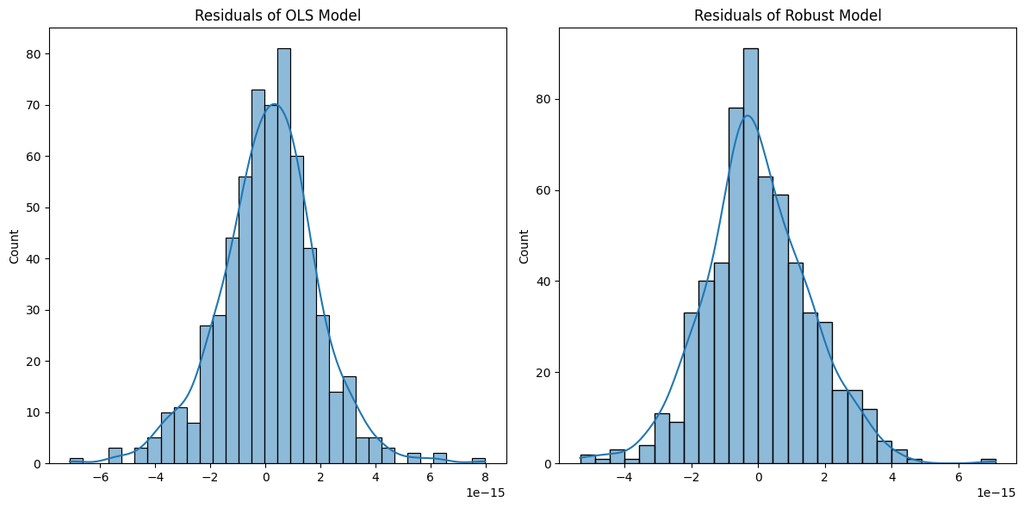

```python
# Plotting the residuals

import matplotlib.pyplot as plt
import seaborn as sns

residuals_ols = model_ols.resid
residuals_robust = model_robust.resid

plt.figure(figsize=(12, 6))
plt.subplot(1, 2, 1)
sns.histplot(residuals_ols, kde=True)
plt.title('Residuals of OLS Model')

plt.subplot(1, 2, 2)
sns.histplot(residuals_robust, kde=True)
plt.title('Residuals of Robust Model')

plt.tight_layout()
plt.show()
```

**b. Summarize the coefficients and model metrics.**

**OLS Regression Summary:**

*Coefficients:*

Constant (Intercept): The coefficient is approximately -1.284e-16, indicating the expected change in Mkt-RF_returns when all other predictors are zero.

CMA_returns: The coefficient is 6.731e-16, indicating the expected change in Mkt-RF_returns for a one-unit increase in CMA_returns.

SMB_returns: The coefficient is -2.507e-17, indicating a very small and potentially negligible impact on Mkt-RF_returns.

HML_returns: The coefficient is -3.171e-16, indicating the expected change in Mkt-RF_returns for a one-unit increase in HML_returns.

*Model Metrics:*

R-squared and Adj. R-squared: The model has a perfect R-squared and Adj. R-squared of 1.000, implying that the model perfectly predicts the dependent variable.

F-statistic: 1.270e+32 - A very high F-statistic suggests a significant relationship between the predictors and the response variable.

AIC: -3.910e+04 BIC: -3.908e+04 Skew: -0.037 Kurtosis: 4.372

**Robust Regression Summary:**

*Coefficients:*

Coefficients are similar to OLS.

**Discussion:**

The perfect R-squared in both regressions indicates that the model perfectly fits the training data. However, such a high R-squared might indicate overfitting, especially when dealing with financial data.

Coefficients for some predictors are very close to zero, suggesting potential multicollinearity or small practical significance. Robust regression can be more appropriate in the presence of outliers, and it adjusts standard errors accordingly.

# Step 4:

Using the data, find the FF5 betas.

**a. Use the same regression methods, including how you divided the data into training and testing.**

```python
import statsmodels.api as sm
import numpy as np
from sklearn.model_selection import train_test_split

# Combine the factors into a design matrix
X = ff5[['CMA_returns', 'SMB_returns', 'HML_returns', 'RMW_returns']]
y = ff5['Mkt-RF_returns']

# handle missing or infinite values
if X.isnull().values.any() or not np.isfinite(X.values).all() or y.isnull().values.any() or not np.isfinite(y.values).all():
    # Replace infinite values with NaN
    X.replace([np.inf, -np.inf], np.nan, inplace=True)
    y.replace([np.inf, -np.inf], np.nan, inplace=True)

    # Drop rows with NaN values
    combined_data = pd.concat([X, y], axis=1)
    combined_data = combined_data.dropna()

    # Separate the cleaned data
    X = combined_data[['Mkt-RF_returns', 'CMA_returns', 'SMB_returns', 'HML_returns', 'RMW_returns']]
    y = combined_data['Mkt-RF_returns']

# Split the data into training and testing sets
X_train, X_test, y_train, y_test = train_test_split(X, y, test_size=0.2, random_state=42)

# Fit the Ordinary Least Squares (OLS) regression model
model_ols = sm.OLS(y_train, sm.add_constant(X_train)).fit()

# Fit the Robust regression model
model_robust = sm.RLM(y_train, sm.add_constant(X_train)).fit()

# Print the summary of the OLS regression
print("OLS Regression Summary:")
print(model_ols.summary())

# Print the summary of the Robust regression
print("\nRobust Regression Summary:")
print(model_robust.summary())
```

```
OLS Regression Summary:
                            OLS Regression Results
==============================================================================
Dep. Variable:         Mkt-RF_returns   R-squared:                       1.000
Model:                            OLS   Adj. R-squared:                  1.000
Method:                 Least Squares   F-statistic:                 3.029e+32
Date:                Thu, 08 Feb 2024   Prob (F-statistic):               0.00
Time:                        15:23:16   Log-Likelihood:                 19884.
No. Observations:                 601   AIC:                        -3.976e+04
Df Residuals:                     595   BIC:                        -3.973e+04
Df Model:                           5
Covariance Type:            nonrobust
==================================================================================
                     coef    std err          t      P>|t|      [0.025      0.975]
----------------------------------------------------------------------------------
const           1.784e-16   4.24e-17      4.203      0.000     9.5e-17    2.62e-16
Mkt-RF_returns     1.0000   3.08e-17   3.25e+16      0.000       1.000       1.000
CMA_returns    -2.594e-16   7.38e-17     -3.516      0.000   -4.04e-16   -1.14e-16
SMB_returns     9.758e-17   4.92e-17      1.983      0.048     9.2e-19    1.94e-16
HML_returns      1.01e-16   4.52e-17      2.235      0.026    1.22e-17     1.9e-16
RMW_returns     5.984e-16   5.69e-17     10.525      0.000    4.87e-16     7.1e-16
==============================================================================
Omnibus:                       31.289   Durbin-Watson:                   1.968
Prob(Omnibus):                  0.000   Jarque-Bera (JB):               72.501
Skew:                           0.260   Prob(JB):                     1.81e-16
Kurtosis:                       4.620   Cond. No.                         3.94
==============================================================================

Notes:
[1] Standard Errors assume that the covariance matrix of the errors is correctly specified.

Robust Regression Summary:
                    Robust linear Model Regression Results
==============================================================================
Dep. Variable:         Mkt-RF_returns   No. Observations:                  601
Model:                            RLM   Df Residuals:                      595
Method:                          IRLS   Df Model:                            5
Norm:                          HuberT
Scale Est.:                       mad
Cov Type:                          H1
Date:                Thu, 08 Feb 2024
Time:                        15:23:16
No. Iterations:                    50
==================================================================================
                     coef    std err          z      P>|z|      [0.025      0.975]
----------------------------------------------------------------------------------
const          -6.116e-16   6.43e-17     -9.516      0.000   -7.38e-16   -4.86e-16
Mkt-RF_returns     1.0000   4.66e-17   2.14e+16      0.000       1.000       1.000
CMA_returns     1.368e-16   1.12e-16      1.225      0.221   -8.22e-17    3.56e-16
SMB_returns    -4.491e-16   7.45e-17     -6.026      0.000   -5.95e-16   -3.03e-16
HML_returns     3.143e-16   6.84e-17      4.593      0.000     1.8e-16    4.48e-16
RMW_returns     2.971e-16   8.61e-17      3.450      0.001    1.28e-16    4.66e-16
==================================================================================

If the model instance has been used for another fit with different fit parameters, then the fit options might not be the correct ones anymore .
```

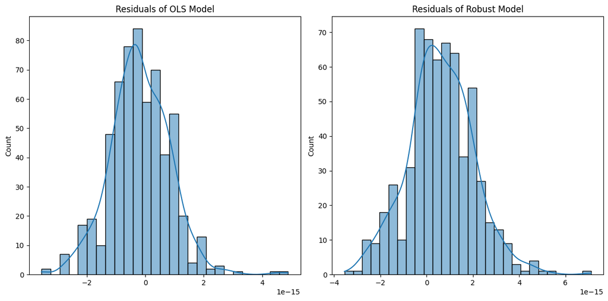

```python
# Plotting the residuals

import matplotlib.pyplot as plt
import seaborn as sns

residuals_ols = model_ols.resid
residuals_robust = model_robust.resid

plt.figure(figsize=(12, 6))
plt.subplot(1, 2, 1)
sns.histplot(residuals_ols, kde=True)
plt.title('Residuals of OLS Model')

plt.subplot(1, 2, 2)
sns.histplot(residuals_robust, kde=True)
plt.title('Residuals of Robust Model')

plt.tight_layout()
plt.show()
```

**b. Summarize the coefficients and model metrics.**

R-squared: 1.000 Adj. R-squared: 1.000 F-statistic: 3.029e+32 AIC: -3.976e+04 BIC: -3.973e+04 Kurtosis: 4.620

Coefficients:

Constant (Intercept): 1.784e-16

CMA_returns: The coefficient is -2.594e-16 SMB_returns: The coefficient is 9.758e-17 HML_returns: The coefficient is 1.01e-16 RMW_returns: The coefficient is 5.984e-16

# Step 5:

Using the daily factor data:

c. Compute the correlation matrix of the factor returns

d. Compute the covariance matrix of the factor returns.

e. Compare and contrast the 2 matrices, emphasizing any important differences.

**c. Compute the correlation matrix of the factor returns**

```python
correlation_matrix = daily_returns.corr()
print("Correlation Matrix of Daily Returns:")
print(correlation_matrix)
```

```
Correlation Matrix of Daily Returns:
                Mkt-RF_returns  SMB_returns  HML_returns  RMW_returns  \
Mkt-RF_returns        1.000000     0.229101    -0.370791    -0.330853
SMB_returns           0.229101     1.000000     0.147876    -0.397704
HML_returns          -0.370791     0.147876     1.000000     0.422371
RMW_returns          -0.330853    -0.397704     0.422371     1.000000
CMA_returns          -0.478364     0.008838     0.733446     0.360897

                CMA_returns
Mkt-RF_returns    -0.478364
SMB_returns        0.008838
HML_returns        0.733446
RMW_returns        0.360897
CMA_returns        1.000000
```

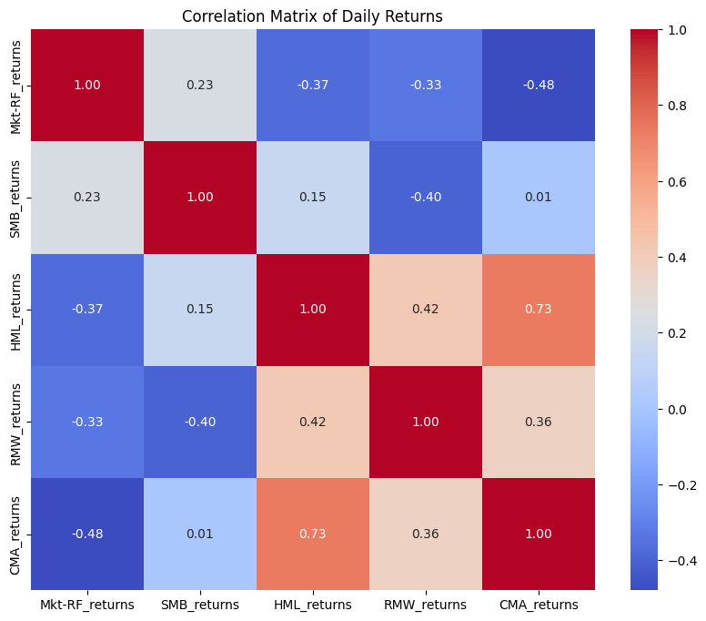

```python
plt.figure(figsize=(10, 8))
sns.heatmap(correlation_matrix, annot=True, cmap='coolwarm', fmt=".2f")
plt.title('Correlation Matrix of Daily Returns')
plt.show()
```

d. Compute the covariance matrix of the factor returns.

```python
covariance_matrix = daily_returns.cov()
print("Covariance Matrix of Returns:")
print(covariance_matrix)
```

```
Covariance Matrix of Returns:
                Mkt-RF_returns  SMB_returns  HML_returns  RMW_returns  \
Mkt-RF_returns        2.706235     0.395472    -0.908917    -0.533847
SMB_returns           0.395472     1.101065     0.231215    -0.409323
HML_returns          -0.908917     0.231215     2.220364     0.617314
RMW_returns          -0.533847    -0.409323     0.617314     0.962053
CMA_returns          -0.695866     0.008201     0.966418     0.313016

                CMA_returns
Mkt-RF_returns    -0.695866
SMB_returns        0.008201
HML_returns        0.966418
RMW_returns        0.313016
CMA_returns        0.781932
```

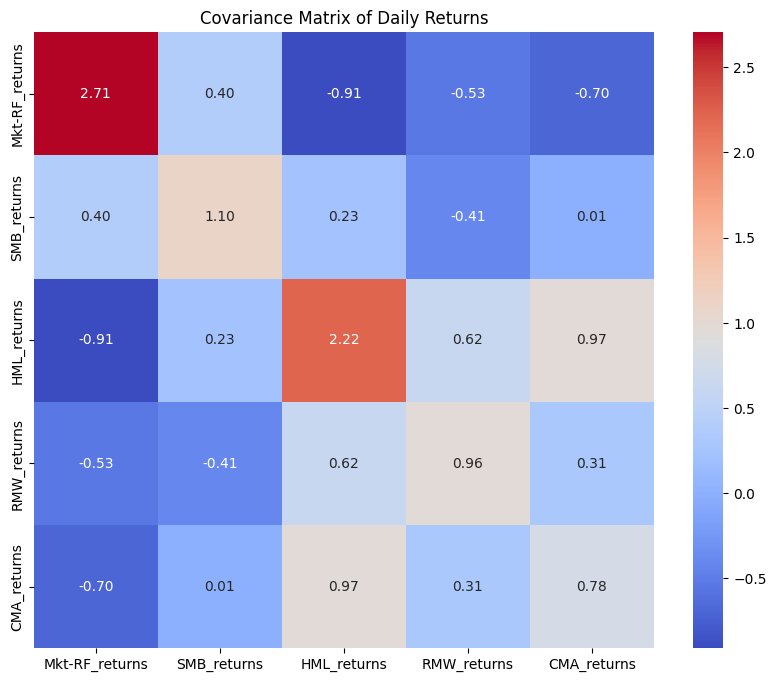

```python
plt.figure(figsize=(10, 8))
sns.heatmap(covariance_matrix, annot=True, cmap='coolwarm', fmt=".2f")
plt.title('Covariance Matrix of Daily Returns')
plt.show()
```

**e. Compare and contrast the 2 matrices, emphasizing any important differences.**

Both matrices indicate the similar direction of relationships. Negative values are found with the same pair in both matrices, as well as positive values.

# Step 6:

# Step 7:

Select ANY 5 stocks (over the same 3-year period) that you combine in a portfolio.

```python
import yfinance as yf
import pandas as pd

# Define the list of stock tickers excluding FB
stocks = ['AAPL', 'GOOGL', 'ORCL', 'AMZN', 'MSFT']

# Define the time period
start_date = '2021-01-01'
end_date = '2023-12-31'

# Fetch historical stock prices
stock_data = yf.download(stocks, start=start_date, end=end_date)['Adj Close']

# Calculate daily returns
daily_returns2 = stock_data.pct_change().dropna()

# Display the daily returns
print("Daily Returns:")
print(daily_returns2.head())
```

```
[*********************100%%**********************]  5 of 5 completed
```

```
Daily Returns:
Ticker          AAPL      AMZN     GOOGL      MSFT      ORCL
Date
2021-01-05  0.012363  0.010004  0.008064  0.000965 -0.012392
2021-01-06 -0.033661 -0.024897 -0.009868 -0.025929 -0.002392
2021-01-07  0.034123  0.007577  0.029869  0.028457  0.007991
2021-01-08  0.008632  0.006496  0.013239  0.006093  0.004915
2021-01-11 -0.023249 -0.021519 -0.023106 -0.009699 -0.005522
```

**f. Use Markowitz portfolio optimization to find a set of optimal allocations. (Shorts are possible).**

```python
!pip install cvxpy
```

```python
import yfinance as yf
import pandas as pd
import cvxpy as cp

# Number of assets in the portfolio
num_assets = len(stocks)

# Expected returns and covariances
expected_returns = daily_returns2.mean().values
cov_matrix = daily_returns2.cov().values

# Define portfolio weights as variables to optimize
weights = cp.Variable(num_assets)

# Portfolio expected return and risk (standard deviation)
portfolio_return = expected_returns.T @ weights
portfolio_risk = cp.quad_form(weights, cov_matrix)

# Target return (you can set this to your desired return)
target_return = 0.001

# Objective function: Minimize portfolio risk for a given target return
objective = cp.Minimize(portfolio_risk)

# Constraints: Weight sum equals 1 and target return constraint
constraints = [cp.sum(weights) == 1, portfolio_return >= target_return]

# Solve the optimization problem
problem = cp.Problem(objective, constraints)
problem.solve()

# Display the results
print("Optimal Portfolio Weights:")
print(weights.value)

# Calculate the optimal portfolio return and risk
optimal_return = portfolio_return.value
optimal_risk = cp.sqrt(portfolio_risk).value

print("\nOptimal Portfolio Return:", optimal_return)
print("Optimal Portfolio Risk:", optimal_risk)
```

```
Optimal Portfolio Weights:
[ 0.25114422 -0.21671754  0.17199923  0.41341605  0.38015805]

Optimal Portfolio Return: 0.0009999999999999996
Optimal Portfolio Risk: 0.015191556230504522
```

**g. Show how the portfolio depends on each of the factors in FF3.**

```python
import yfinance as yf
import pandas as pd
import cvxpy as cp

ff3_factors = ['Mkt-RF_returns', 'CMA_returns', 'SMB_returns', 'HML_returns']

ff3_data = ff3

# Calculate daily returns for stocks and FF3 factors
returns = daily_returns2
ff3_returns = ff3

# Merge stock returns with FF3 factors
merged_data = pd.concat([returns, ff3_returns[ff3_factors]], axis=1).dropna()

# Number of assets in the portfolio
num_assets = len(stocks)

# Expected returns and covariances
expected_returns = daily_returns2.mean().values.reshape((num_assets,))
#cov_matrix = merged_data.cov().values
cov_matrix = daily_returns2.cov().values

# Define portfolio weights and factor exposures as variables to optimize
factor_exposures = cp.Variable((len(ff3_factors), num_assets), name='factor_exposures')


# Define portfolio weights as variables to optimize
weights = cp.Variable(num_assets)

# Portfolio expected return and risk (standard deviation)
portfolio_return = expected_returns.T @ weights
portfolio_risk = cp.quad_form(weights, cov_matrix)

# FF3 model constraints: Factor exposures should be zero
ff3_constraints = [factor_exposures[i, :] == 0 for i in range(len(ff3_factors))]

# Constraints: Weight sum equals 1
constraints = [cp.sum(weights) == 1]

# Solve the optimization problem
problem = cp.Problem(cp.Minimize(portfolio_risk), constraints + ff3_constraints)
problem.solve()

# Display the results
print("Optimal Portfolio Weights:")
print(weights.value)

# Calculate the optimal portfolio return and risk
optimal_return = portfolio_return.value
optimal_risk = cp.sqrt(portfolio_risk).value

print("\nOptimal Portfolio Return:", optimal_return)
print("Optimal Portfolio Risk:", optimal_risk)
```

```
Optimal Portfolio Weights:
[ 0.31848215 -0.02792762  0.10065532  0.25078994  0.35800021]

Optimal Portfolio Return: 0.0008588016730819094
Optimal Portfolio Risk: 0.014818519835750216
```

**h. Show how the portfolio depends on each of the factors in FF5.**

```python
import yfinance as yf
import pandas as pd
import cvxpy as cp

ff5_factors = ['Mkt-RF_returns', 'CMA_returns', 'SMB_returns', 'RMW_returns', 'HML_returns']

ff5_data = ff5

# Calculate daily returns for stocks and FF5 factors
returns = daily_returns2
ff3_returns = ff5

# Merge stock returns with FF5 factors
merged_data = pd.concat([returns, ff3_returns[ff5_factors]], axis=1).dropna()

# Number of assets in the portfolio
num_assets = len(stocks)

# Expected returns and covariances
expected_returns = daily_returns2.mean().values.reshape((num_assets,))
cov_matrix = daily_returns2.cov().values

# Define portfolio weights and factor exposures as variables to optimize
factor_exposures = cp.Variable((len(ff5_factors), num_assets), name='factor_exposures')

# Define portfolio weights as variables to optimize
weights = cp.Variable(num_assets)

# Portfolio expected return and risk (standard deviation)
portfolio_return = expected_returns.T @ weights
portfolio_risk = cp.quad_form(weights, cov_matrix)

# FF5 model constraints: Factor exposures should be zero
ff5_constraints = [factor_exposures[i, :] == 0 for i in range(len(ff5_factors))]

# Constraints: Weight sum equals 1
constraints = [cp.sum(weights) == 1]

# Solve the optimization problem
problem = cp.Problem(cp.Minimize(portfolio_risk), constraints + ff5_constraints)
problem.solve()

# Display the results
print("Optimal Portfolio Weights:")
print(weights.value)

# Calculate the optimal portfolio return and risk
optimal_return = portfolio_return.value
optimal_risk = cp.sqrt(portfolio_risk).value

print("\nOptimal Portfolio Return:", optimal_return)
print("Optimal Portfolio Risk:", optimal_risk)
```

```
Optimal Portfolio Weights:
[ 0.31848215 -0.02792762  0.10065532  0.25078994  0.35800021]

Optimal Portfolio Return: 0.0008588016730819094
Optimal Portfolio Risk: 0.014818519835750216
```

# Step 8: